# Homework 1

Charlotte Sielewicz

2022-03-31

## **Machine Learning Main Ideas**

Please answer the following questions. Be sure that your solutions are clearly marked and that your document is neatly formatted.

You don’t have to rephrase everything in your own words, but if you quote directly, you should cite whatever materials you use (this can be as simple as “from the lecture/page # of book”).

### **Question 1:**

Define supervised and unsupervised learning. What are the difference(s) between them?

**Supervised learning utilizes the actual data** $Y$ **to indicate if a model accurately predicts data. Unsupervised learning does not have data** $Y$ **to ensure accurate predictions.**

### **Question 2:**

Explain the difference between a regression model and a classification model, specifically in the context of machine learning.

**Regression models generally have a quantitative responses while classification models have qualitative responses.**

*(Lecture_day2 pg. 1 and ISLR textbook pg. 28).*

### **Question 3:**

Name two commonly used metrics for regression ML problems. Name two commonly used metrics for classification ML problems.

### **Question 4:**

As discussed, statistical models can be used for different purposes. These purposes can generally be classified into the following three categories. Provide a brief description of each.

- Descriptive models: **Models trends in order to visualize data.**
- Inferential models: **Tests theories to better understand relationships between variables.**
- Predictive models: **Predicts results with minimal error.**

  *(Lecture_day2 pg. 7)*

### **Question 5:**

Predictive models are frequently used in machine learning, and they can usually be described as either mechanistic or empirically-driven. Answer the following questions.

- Define mechanistic. Define empirically-driven. How do these model types differ? How are they similar?

  **Mechanistic models are based on theories and do not find the true, unknown,** $f$. **They are however much more flexible. Empirically-driven models are used to develop theories based on real life data. They are much less flexible and require many more observations. They also often result in over fitting.**
- In general, is a mechanistic or empirically-driven model easier to understand? Explain your choice.

  **Empirically-driven model is easier to understand because it is based on large amounts of data and has much more flixability.**
- Describe how the bias-variance tradeoff is related to the use of mechanistic or empirically-driven models.

### **Question 6:**

A political candidate’s campaign has collected some detailed voter history data from their constituents. The campaign is interested in two questions:

- Given a voter’s profile/data, how likely is it that they will vote in favor of the candidate?
- How would a voter’s likelihood of support for the candidate change if they had personal contact with the candidate?

Classify each question as either predictive or inferential. Explain your reasoning for each.

**Question 1 is a predictive question. This is because it is aiming to predict an outcome based on given data.**

**Question 2 is an inferential question. This is because it is aiming to test a theory that knowing a candidate changes the support of the voter.**

## **Exploratory Data Analysis**

This section will ask you to complete several exercises. For this homework assignment, we’ll be working with the `mpg` data set that is loaded when you load the tidyverse. Make sure you load the tidyverse and any other packages you need.

Exploratory data analysis (or EDA) is not based on a specific set of rules or formulas. It is more of a state of curiosity about data. It’s an iterative process of:

- generating questions about data
- visualize and transform your data as necessary to get answers
- use what you learned to generate more questions

A couple questions are always useful when you start out. These are “what variation occurs within the variables,” and “what covariation occurs between the variables.”

You should use the tidyverse and `ggplot2` for these exercises.

### **Exercise 1:**

We are interested in highway miles per gallon, or the `hwy` variable. Create a histogram of this variable. Describe what you see/learn.

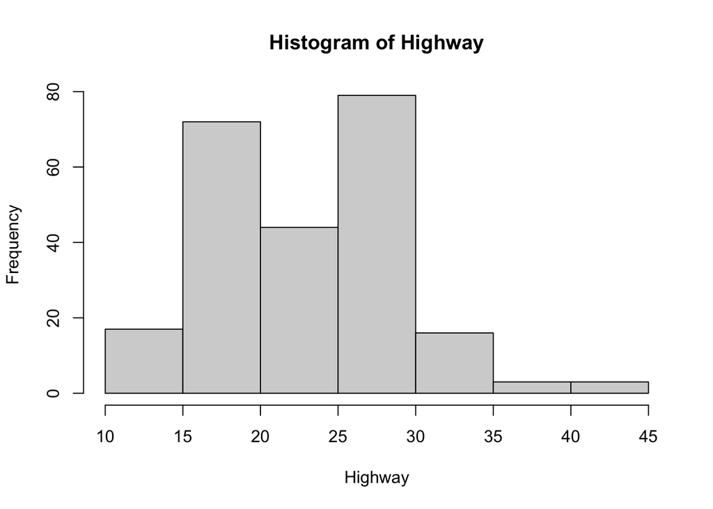

```r
Highway <- mpg$hwy
hist(Highway)
```

**The histogram shows that the majority of drivers on the highway get under 30 miles per gallon on the highway and very few get between 35 and 45 miles per gallon on the highway.**

### **Exercise 2:**

Create a scatterplot. Put `hwy` on the x-axis and `cty` on the y-axis. Describe what you notice. Is there a relationship between `hwy` and `cty`? What does this mean?

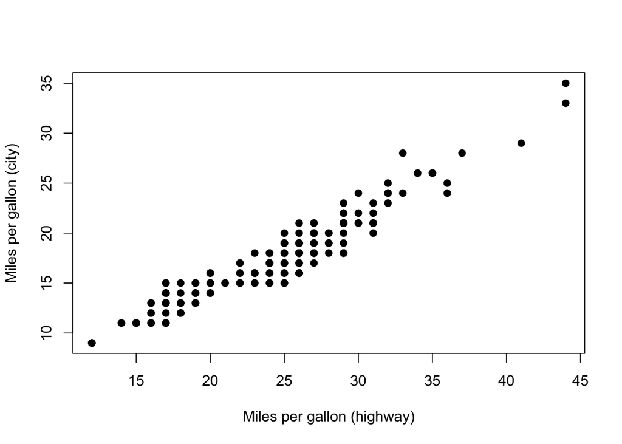

```r
plot(mpg$hwy, mpg$cty,
     xlab = "Miles per gallon (highway)",
     ylab = "Miles per gallon (city)",
     pch=19)
```

**The scatterplot shows a linear correlation between `hwy` and `cty` which indicates a relationship. Based on the scatterplot, while all cars get much better mpg on the highway, if a car has better mpg on the highway than other cars it will most likely have better mpg in the city as well. This can also be flipped.**

### **Exercise 3:**

Make a bar plot of `manufacturer`. Flip it so that the manufacturers are on the y-axis. Order the bars by height. Which manufacturer produced the most cars? Which produced the least?

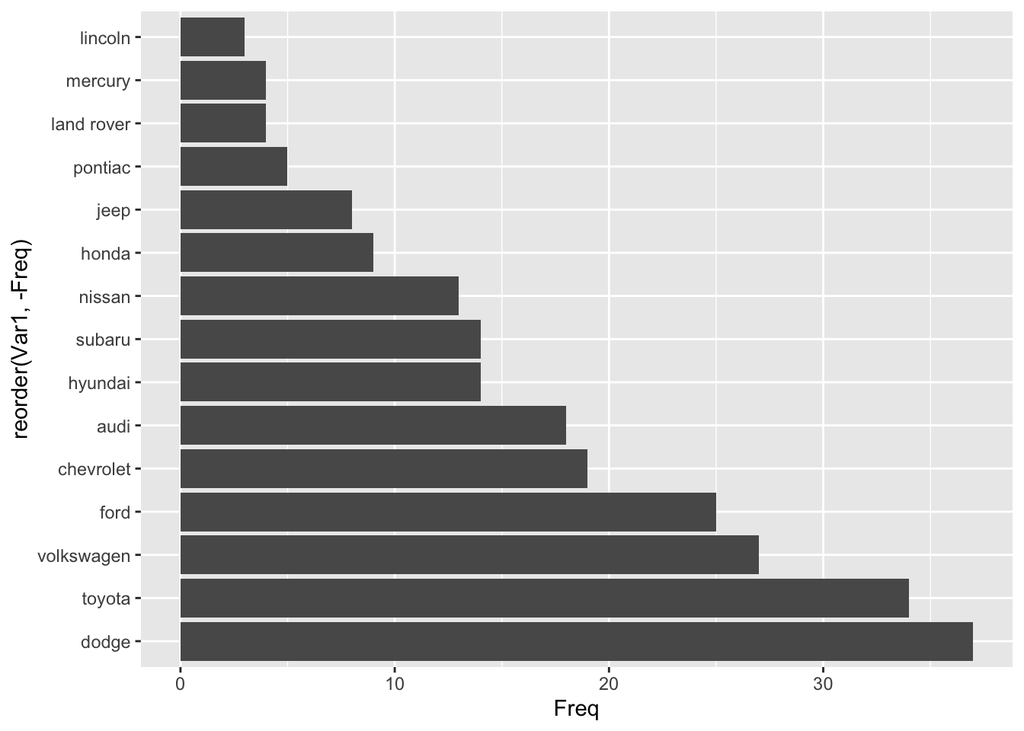

```r
counts <- table(mpg$manufacturer)
data <- data.frame(counts)
ggplot(data,aes(x= reorder(Var1,-Freq),Freq))+geom_bar(stat ="identity")+coord_flip()
```

**Dodge produces the most cars while Lincoln produces the least.**

### **Exercise 4:**

Make a box plot of `hwy`, grouped by `cyl`. Do you see a pattern? If so, what?

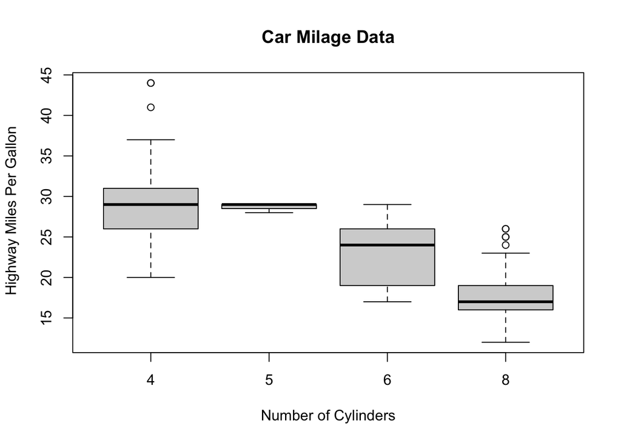

```r
boxplot(hwy~cyl,data=mpg, main="Car Milage Data",
   xlab="Number of Cylinders", ylab=" Highway Miles Per Gallon")
```

**The box plot shows in general the fewer cylinder a car has the better highway mpg is achieved.**

### **Exercise 5:**

Use the `corrplot` package to make a lower triangle correlation matrix of the `mpg` dataset. (Hint: You can find information on the package [here.](https://cran.r-project.org/web/packages/corrplot/vignettes/corrplot-intro.html))

Which variables are positively or negatively correlated with which others? Do these relationships make sense to you? Are there any that surprise you?

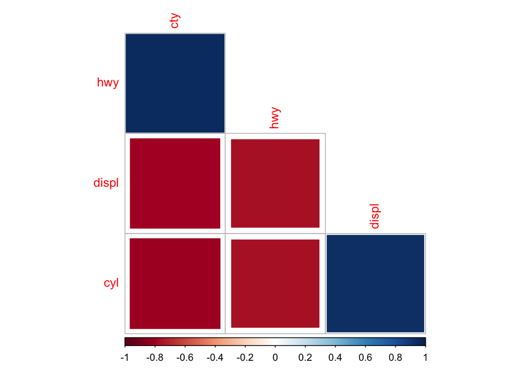

```r
MPG <- mpg
keeps <- c("displ","cyl", "cty", "hwy")
MPG = MPG[keeps]
M = cor(MPG)
corrplot(M, method = 'square', order = 'FPC', type = 'lower', diag = FALSE)
```

**`hwy` and `cty` are positively correlated with each other, as well as `cyl` and `displ`. All others are negatively correlated with each other. These results are not all that surprising.**